# Parte4 - Salário dos Profissionais de TI no Brasil

Arthur Sena

04/21/2015

```r
library("ggplot2")
```

# Descrição dos dados:

Os dados foram coletados através de um formulário no google. Tais dados contem informações sobre o salário e outras informações à respeito de algumas profissões de TI no Brasil. Ao todo foram coletados 162 obervações com 12 variáveis cada. Na figura abaixo, é possivel visualizar uma pequena amostra dos dados.

```r
salariosTI <- read.csv("salarios-ti-refinado.csv")
head(salariosTI[,c(2,3,4,6,12)])
```

```
##           Cidade UF Salario.Bruto Tempo.de.Empresa       Regiao
## 1 Campina Grande PB         42120              5.0     Nordeste
## 2       Brasilia DF         15000             12.0 Centro-oeste
## 3         Recife PE         13787              1.0     Nordeste
## 4       Brasilia DF         12960              0.5 Centro-oeste
## 5 Belo Horizonte MG          9500              3.0      Sudeste
## 6       Campinas SP          8500              1.0      Sudeste
```

Para uma melhor visualização, algumas colunas/variáveis foram cortada da figura acima, contudo todo o conjunto de colunas/variaveis podem ser vistas abaixo:

```r
colnames(salariosTI)
```

```
##  [1] "Column"                           "Cidade"
##  [3] "UF"                               "Salario.Bruto"
##  [5] "Horas.Diarias"                    "Tempo.de.Empresa"
##  [7] "Experiencia.Profissional"         "Iniciativa.Privada.ou.Concursado"
##  [9] "Cargo"                            "Formacao"
## [11] "Pos.Graduacao.ou.Certificacao"    "Regiao"
```

Antes de se fazer uma análise mais aprofundada nos nossos dados, é sempre de bom tom procurar por uma ou mais observações estranhas ou fora do padrão. Seguindo tal conceito, é possível notar que uma da observações apresenta uma comportamento um tanto peculiar à respeito da variável Salario Bruto.

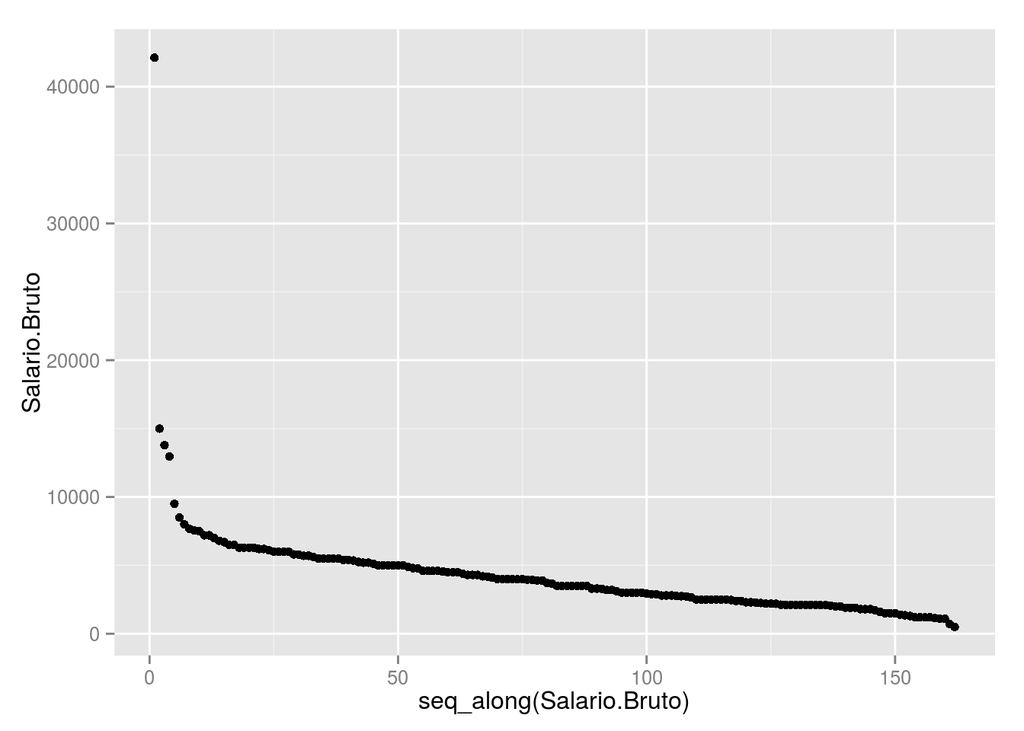

```r
qplot(data = salariosTI, y = Salario.Bruto)
```

O gráfico acima apresenta todas as observações da variável “Salario.Bruto”. É possível notar que a grande maioria dos dados esta dentro de um determinado “range”, contudo existe uma observação que apresenta um comportamento bastante diferenciado, onde a mesma se encontra isolada na parte superior do gráfico. Tal observacao, esta ligada a algum profissional que tem um salário bruto maior do que R$40,000 reais. Por apresentar tal comportamento, essa observacão é chamada de “outlier”.

Um bom analista de dados deve ter cuidado com outlier’s, pois dependo da pergunta que é feita ao seus conjunto de dados, os outlier’s podem influenciar a sua resposta de uma maneira errônea. Assim sendo, é aconselhável usar estratégias que possam dimunuir ou eliminar a influência dessas observações.

# Respondendo algumas perguntas

Com esse dados em mãos é possível fazer algumas consultas ao nossos dados afim de tentar responder algumas perguntas. Assim sendo, eu selecionei quatro perguntas que eu considero interessantes e que podem nos dar uma visão do cenário no qual os profissionais de TI se encontram no Brasil. As perguntas e suas, respectivas, respostas se encontram abaixo:

Obs.: Em todas as perguntas abaixo, eu utilizei a mediana como estratégia de diminuir a influência dos outlier’s nas minhas respostas.

# 1) Qual o cargo que ganha mais na área de TI ?

Para responder tal pergunta, precisamos primeiro agrupar os dados por cargo, onde iremos calcular a mediana de salário por cargo.

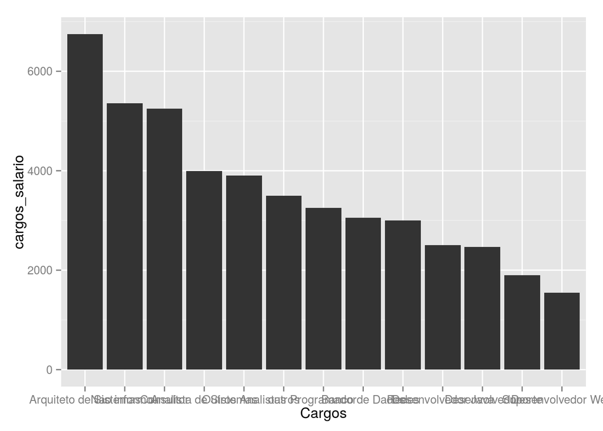

```r
 cargos <- levels(salariosTI$Cargo)
 cargos_salario <- sapply(cargos,function(cargo){
      salario_cargo <- salariosTI[salariosTI$Cargo == cargo,]
      median(salario_cargo$Salario.Bruto)
  })
 cargos_salario <- as.data.frame(cargos_salario)
 cargos_salario <- cbind(Cargo = rownames(cargos_salario), cargos_salario)
 rownames(cargos_salario) <- NULL
 chart <- ggplot(cargos_salario, aes(Cargos,cargos_salario))
 ordenar <- reorder(cargos_salario$Cargo,-cargos_salario$cargos_salario)
 chart + geom_bar(stat = "identity",aes(ordenar))
```

Visualizando o gráfico acima, podemos notar que o Arquiteto de Sistemas é o profissional que apresenta a maior mediana salarial segundo o nosso conjunto de dados e, por essa razão, o cargo de maior salário.

# 2) Apresentar uma pós-graduação ou certificado aumenta o salário ? Se sim, quanto aumenta ?

Para solucionar essa pergunta, devemos primeiro dividir os nossos dados em dois conjuntos: Profissionais **com** Pós ou certificado e Prossinais **sem** Pós ou certificado. Após tal divisão, poderemos comparar a mediana salarial de ambos os grupos.

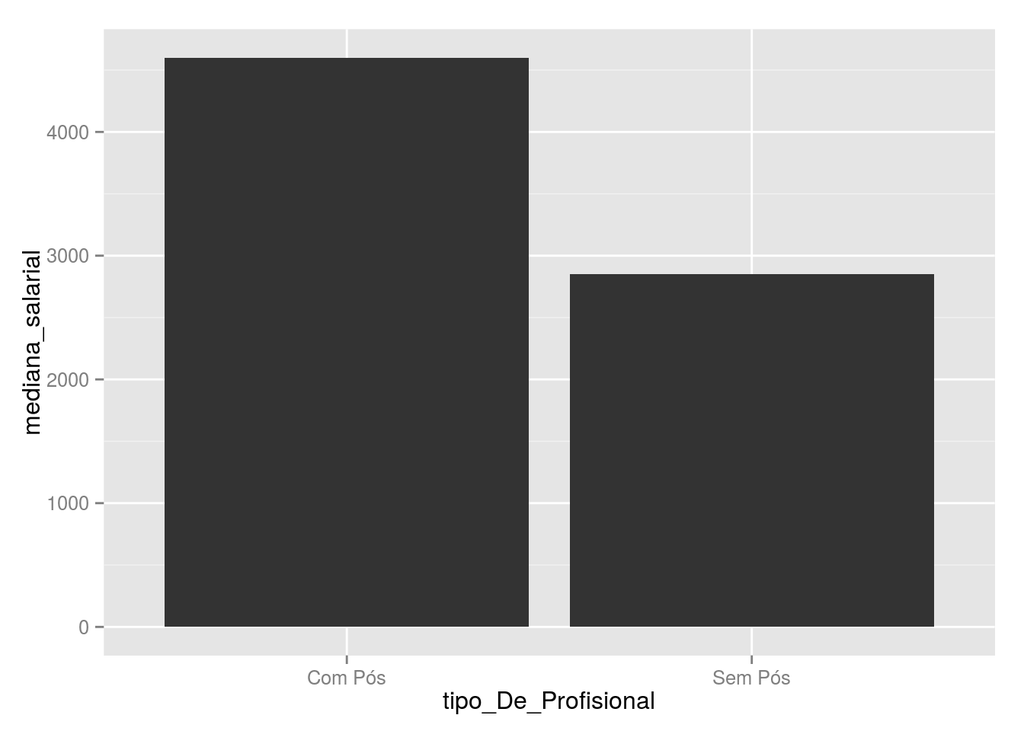

```r
profissional_sem_pos <- salariosTI[salariosTI$Pos.Graduacao.ou.Certificacao == FALSE,]
profissional_com_pos <- salariosTI[salariosTI$Pos.Graduacao.ou.Certificacao == TRUE,]

medianaSalarial_sem_pos <- median(profissional_sem_pos$Salario.Bruto)
medianaSalarial_com_pos <- median(profissional_com_pos$Salario.Bruto)


mediana_salarial <- c(medianaSalarial_sem_pos,medianaSalarial_com_pos)
    tipo_De_Profisional <- c("Sem Pós","Com Pós")
    data <- data.frame(tipo_De_Profisional,mediana_salarial)
    chart <- ggplot(data, aes(tipo_De_Profisional,mediana_salarial))
    chart + geom_bar(stat = "identity")
```

Visualizando o gráfico acima podemos observar que a mediana salarial de profissionais com Pós ou algum tipo de certificado é maior do que a os profissionais sem Pós ou certificado. Onde, se calcularmos a diferença das duas medianas, podemos dizer que é um salário de, aproximadamente, R$ 1750,00 reais a mais com prova o código abaixo:

```r
 print(medianaSalarial_com_pos-medianaSalarial_sem_pos)
```

```
## [1] 1750
```

# 3) Qual a média salarial de um bacharel em computação ?

Nessa consulta, devemos filtrar os profissionais que apresentam bacharel em computacão e calcularmos a mediana salarial de tais profissionais.

```r
      bacharel_profissional <- salariosTI[salariosTI$Formacao == "Bacharel em Ciência da Computação",]
      mediana_salarial <- median(bacharel_profissional$Salario.Bruto)
      print(mediana_salarial)
```

```
## [1] 4000
```

Ou seja, segundo os nosso dados, um bacharel em computação apresentam uma mediana salarial de R$4000,00 reais

# 4) Entre iniciativa pública e privada, qual delas apresenta o melhor salário e de quanto é a diferença?

Mais uma vez precisamos agrupar os dados em dois grupos e calcular a mediana salarial para cada um deles

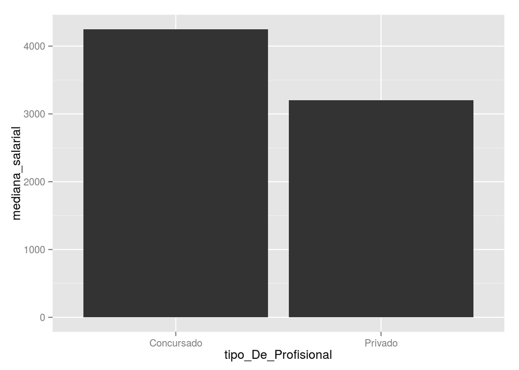

```r
    privado <- salariosTI[salariosTI$Iniciativa.Privada.ou.Concursado == "Iniciativa Privada",]
    publico <- salariosTI[salariosTI$Iniciativa.Privada.ou.Concursado == "Concursado",]

    medianaSal_privado <- c(median(privado$Salario.Bruto))
    medianaSal_publico <- c(median(publico$Salario.Bruto))

    mediana_salarial <- c(medianaSal_publico,medianaSal_privado)
    tipo_De_Profisional <- c("Concursado","Privado")
    data <- data.frame(tipo_De_Profisional,mediana_salarial)
    chart <- ggplot(data, aes(tipo_De_Profisional,mediana_salarial))
    chart + geom_bar(stat = "identity")
```

Visualizando o gráfico acima, podemos observar uma diferença entre os salarios da iniciativa privada e pública, onde a inciativa pública apresenta uma opção salarial melhor do que a privada. A diferença entre elas pode ser visualizada no código abaixo.

```r
    print(medianaSal_publico -  medianaSal_privado)
```

```
## [1] 1050
```